# Canada: COVID-19 vaccine and booster attitudes and motivations in adults with physical chronic health conditions

## INTRODUCTION

Covid-19 vaccines have become wide-spread in the Western world beginning of 2021. To date, Canada’s vaccine uptake is among leading in the world, with over 75% of eligible population vaccinated.

#### Aims:

Using Canadian representative samples, we aimed

1. to explore attitudes about the COVID-19 vaccine booster doses among the Canadian adult population with and without physical chronic health conditions, and
2. to understand what are the motivations for vaccine uptake and factors associated with COVID-19 vaccine resistance among individuals with physical chronic health conditions.

## METHOD

The present study is part of a larger International COVID‐19 Awareness and Responses Evaluation (iCARE) study, which is a global multi‐phase research survey conducted through the Montreal Behavioural Medicine Centre. Find more about the study and materials at www.iCAREstudy.com.

## RESULTS

### Sample

NB - this automatic demographic table does not contain weights therefore the differences between the groups (t-test and chi2) will be recalculated.

More complete table is available in the separate file on the same repository.

```
##                          Stratified by chronic_dummy
##                           0             1             p      test
##   n                        3455          2554
##   age_yrs (mean (SD))     43.43 (15.54) 54.64 (15.47) <0.001
##   sex (%)                                              0.057
##      Female                1819 (52.8)   1265 (49.6)
##      Male                  1623 (47.1)   1279 (50.2)
##      Other                    5 ( 0.1)      4 ( 0.2)
##   edu (%)                                             <0.001
##      College               1767 (51.4)   1217 (47.9)
##      Graduate               635 (18.5)    396 (15.6)
##      Never been               1 ( 0.0)      1 ( 0.0)
##      Primary                 27 ( 0.8)     26 ( 1.0)
##      Secondary             1005 (29.3)    899 (35.4)
##   hoinc (%)                                           <0.001
##      Bottom 3rd             665 (23.1)    728 (32.6)
##      Middle 3rd            1746 (60.7)   1217 (54.5)
##      Top 3rd                465 (16.2)    288 (12.9)
##   province_full (%)                                    0.002
##      Alberta                387 (11.2)    314 (12.3)
##      British Columbia       494 (14.3)    308 (12.1)
##      Manitoba               134 ( 3.9)    101 ( 4.0)
##      New Brunswick           62 ( 1.8)     68 ( 2.7)
##      Newfoundland            47 ( 1.4)     40 ( 1.6)
##      Nova Scotia             78 ( 2.3)     85 ( 3.3)
##      Ontario               1330 (38.5)    994 (38.9)
##      Prince Edward Island    13 ( 0.4)      8 ( 0.3)
##      Quebec                 827 (23.9)    553 (21.7)
##      Saskatchewan            83 ( 2.4)     83 ( 3.2)
##   chronic_descriptive (%)                                NaN
##      Autoimmune               0 ( NaN)    212 ( 8.3)
##      Cancer                   0 ( NaN)     77 ( 3.0)
##      Diabetes                 0 ( NaN)    161 ( 6.3)
##      Heart disease            0 ( NaN)    488 (19.1)
##      Hypertension             0 ( NaN)    876 (34.3)
##      Lung disease             0 ( NaN)    584 (22.9)
##      Obesity                  0 ( NaN)    121 ( 4.7)
##      Other                    0 ( NaN)     35 ( 1.4)
##   chronic_multi = 1 (%)       0 ( 0.0)   1182 (46.3)  <0.001
```

### Vaccine uptake and booster doses

| Chronic illness | Vaccine status | N | Proportion |
| --- | --- | --- | --- |
| 0 | No | 491 | 14.42 |
| 0 | Yes (fully) | 1682 | 49.38 |
| 0 | Yes (partially) | 1233 | 36.20 |
| 1 | No | 251 | 9.86 |
| 1 | Yes (fully) | 1343 | 52.77 |
| 1 | Yes (partially) | 951 | 37.37 |

Canadian with chronic health conditions demonstrate positive attitudes toward COVID-19 vaccine boosters, only 5% reported being somewhat or extremely unlikely to take the booster dose, compared to 10% of health individuals.

| Chronic illness | Vaccine status | N | Proportion |
| --- | --- | --- | --- |
| 0 | Likely | 1241 | 89.73 |
| 0 | Unlikely | 142 | 10.27 |
| 1 | Likely | 1018 | 94.96 |
| 1 | Unlikely | 54 | 5.04 |

### Vaccine motivations among Canadian with physical chronic health conditions

#### Swap the axis so that is shows %

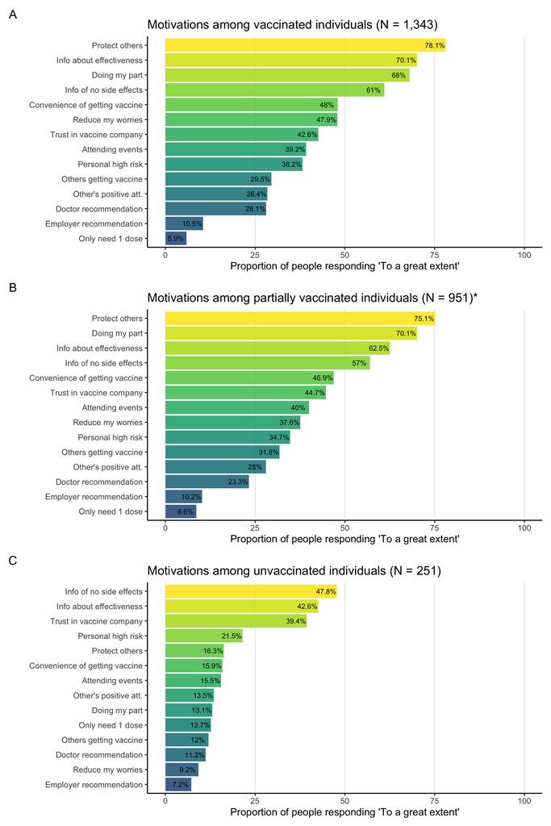

## DISCUSSION

These insights provide important information on how healthcare professionals, policymakers as well as all the relevant stakeholders may need to structure their vaccine messaging in order to encourage the vaccine uptake among the most vulnerable and at risk populations.